# 7. Network Flow I

Algorithm II

7. Network Flow I

WU Xiaokun 吴晓堃

xkun.wu [at] gmail

2021/11/12

## Flow and Cut

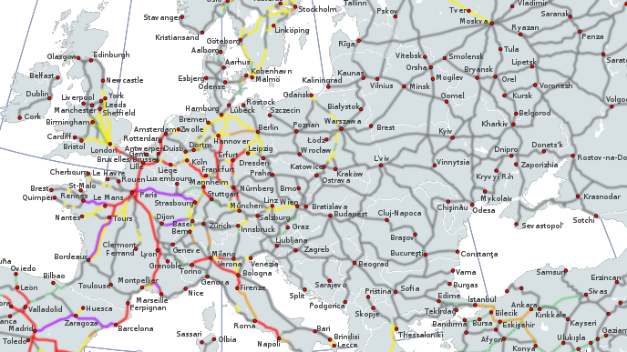

## Flow and Cut - supply

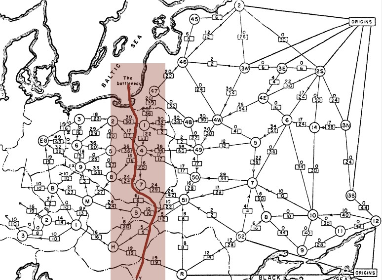

# Max-flow and min-cut problems

## Flow network

A **flow network** is a tuple $G = (V, E, s, t, c)$.

- Digraph $(V, E)$ with source $s \in V$ and sink $t \in V$.
- Capacity $c(e) \ge 0$ for each $e \in E$.

**Intuition**. Material flowing through a transportation network; material originates at source and is sent to sink.

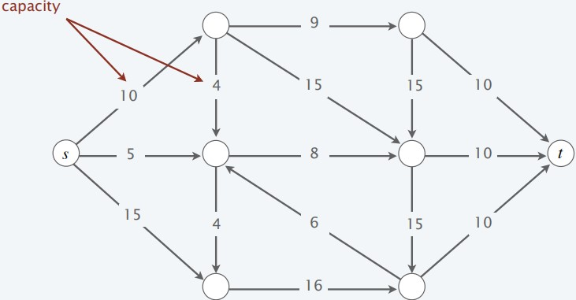

## Minimum-cut problem

**Def**. An **st-cut (cut)** is a partition $(A, B)$ of the nodes with $s \in A$ and $t \in B$.

**Def**. Its capacity is the sum of the capacities of the edges from $A$ to $B$.

- $cap(A,B) = \sum_{e\ \text{out}\ A} c(e)$

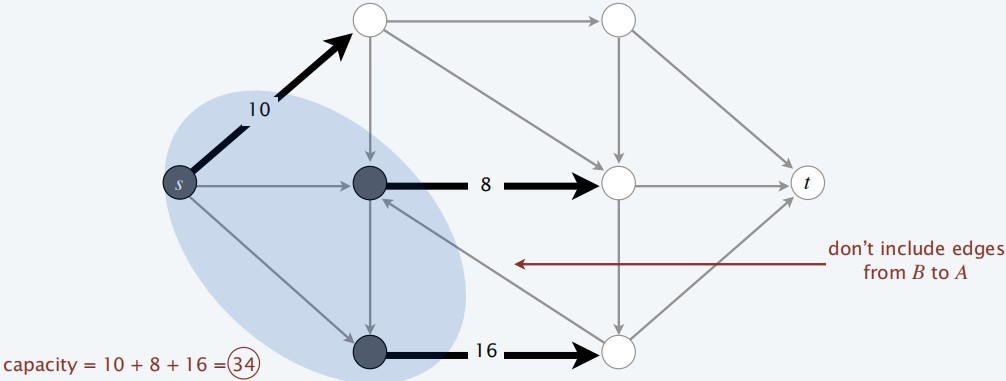

**Min-cut problem**. Find a cut of minimum capacity.

## Maximum-flow problem

**Def**. An **st-flow (flow)** $f$ is a function that satisfies:

- [**capacity**] For each $e \in E$: $0 \le f(e) \le c(e)$
- [**flow conservation**] For each $v \in V - \{s, t\}$: $\sum_{e\ \text{into}\ v} f(e) = \sum_{e\ \text{out}\ v} f(e)$

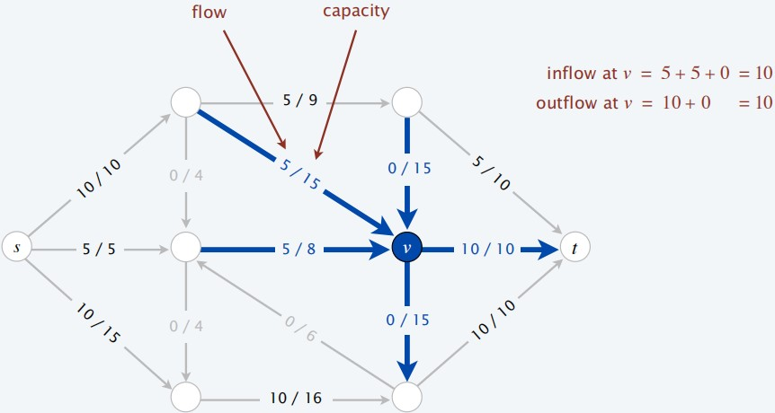

## Maximum-flow problem (cont.)

**Def**. The **value** of a flow $f$ is: $val(f) = \sum_{e\ \text{out}\ s} f(e) - \sum_{e\ \text{into}\ s} f(e)$

**Max-flow problem**. Find a flow of maximum value.

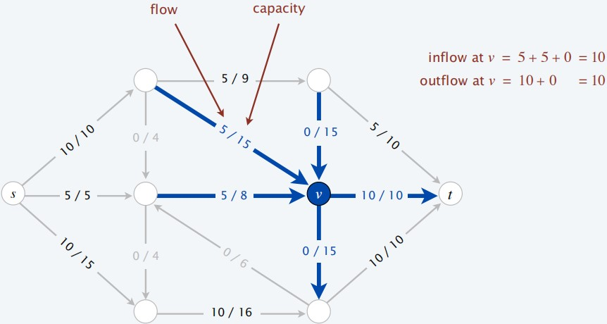

# Ford-Fulkerson algorithm

## Toward a max-flow algorithm

**Greedy algorithm**.

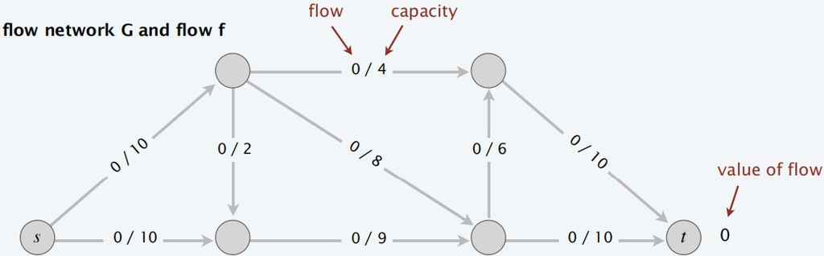

- Start with $f(e) = 0$ for each edge $e \in E$.

## Toward a max-flow algorithm

**Greedy algorithm**.

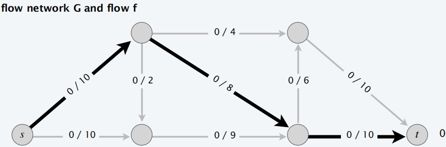

- Start with $f(e) = 0$ for each edge $e \in E$.
- Find an $s \leadsto t$ path $P$ where each edge has $f(e) < c(e)$.

## Toward a max-flow algorithm

**Greedy algorithm**.

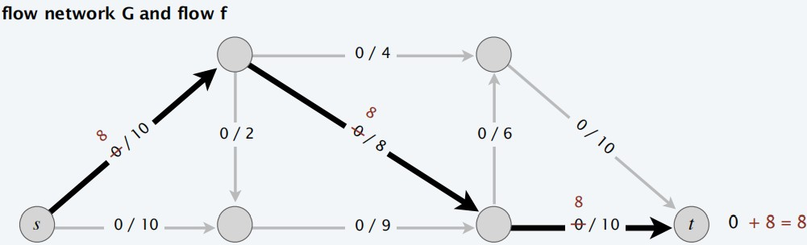

- Start with $f(e) = 0$ for each edge $e \in E$.
- Find an $s \leadsto t$ path $P$ where each edge has $f(e) < c(e)$.
- Augment flow along path $P$.

## Toward a max-flow algorithm

**Greedy algorithm**.

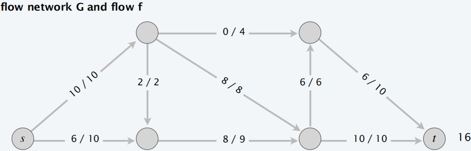

- Start with $f(e) = 0$ for each edge $e \in E$.
- Find an $s \leadsto t$ path $P$ where each edge has $f(e) < c(e)$.
- Augment flow along path $P$.
- Repeat until you get stuck.

Ending flow value = 16

## Toward a max-flow algorithm

**Greedy algorithm**.

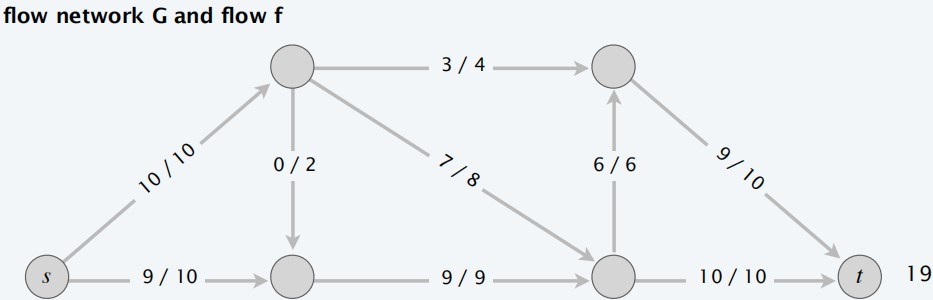

- Start with $f(e) = 0$ for each edge $e \in E$.
- Find an $s \leadsto t$ path $P$ where each edge has $f(e) < c(e)$.
- Augment flow along path $P$.
- Repeat until you get stuck.

But max-flow value = 19

## Why the greedy algorithm fails

**Q**. Why does the greedy algorithm fail?  
**A**. Once greedy algorithm increases flow on an edge, it never decreases it.

**Ex**. Consider flow network $G$.

- Max flow $f^\ast$ has $f^\ast(v, w) = 0$.
- Greedy algorithm could choose $s \rightarrow v \rightarrow w \rightarrow t$ as first path.

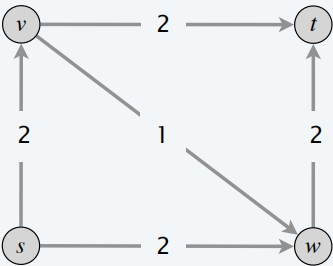

**Bottom line**. Need some mechanism to “undo” a bad decision.

## Residual network

**Original edge**. $e = (u, v) \in E$.

- Flow $f(e)$; Capacity $c(e)$.

**Reverse edge**. $e^{-1} = (v, u)$.

- “Undo” flow sent.

**Residual capacity**.

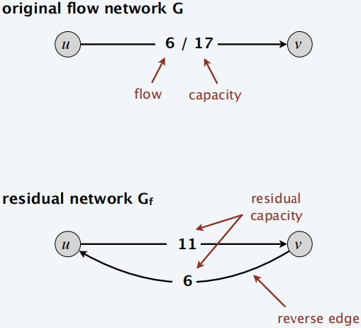

## Residual network (cont.)

**Residual network**. $G_f = (V, E_f , s, t, c_f )$.

- $E_f = \{e: f(e) < c(e)\} \cup \{e^{-1}: f (e) > 0\}$.
- **Key property**: $f'$ is a flow in $G_f$ iff $f + f'$ is a flow in $G$.

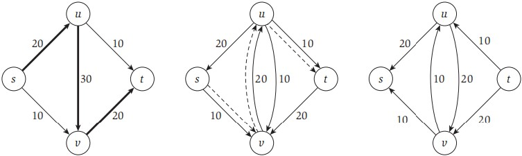

## Augmenting path

**Def**. An **augmenting path** is a simple $s \leadsto t$ path in the residual network $G_f$.

**Def**. The **bottleneck capacity** of an augmenting path $P$ is the *minimum residual capacity* of any edge in $P$.

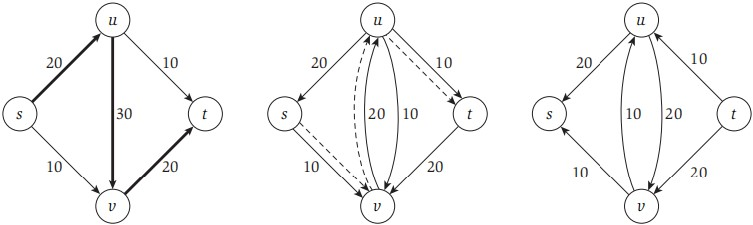

**Key property**. Let $f$ be a flow and let $P$ be an augmenting path in $G_f$. Then, after calling $f'$ = `AUGMENT`($f, c, P$), the resulting $f'$ is a flow and $val(f') = val(f) + bottleneck(G_f, P)$.

## Augmenting path: algorithm

**Key property**. Let $f$ be a flow and let $P$ be an augmenting path in $G_f$. Then, after calling $f'$ = `AUGMENT`($f, c, P$), the resulting $f'$ is a flow and $val(f') = val(f) + bottleneck(G_f, P)$.

`AUGMENT`($f, c, P$)

1. $\Delta$ = bottleneck capacity of augmenting path $P$.
2. FOREACH edge $e \in P$:
   1. IF ($e \in E$) $f(e) = f(e) + \Delta$;
   2. ELSE $f(e^{-1}) = f(e^{-1}) - \Delta$;
3. RETURN f;

## Ford-Fulkerson algorithm

Ford-Fulkerson augmenting path algorithm.

- Start with $f(e) = 0$ for each edge $e \in E$.
- Find an $s \leadsto t$ path $P$ in the residual network $G_f$ .
- Augment flow along path $P$.
- Repeat until you get stuck.

`FORD-FULKERSON`($G$)

1. FOREACH edge $e \in E$: $f(e) = 0$;
2. $G_f$ = residual network of $G$ with respect to flow $f$;
3. WHILE (there exists an $s \leadsto t$ path $P$ in $G_f$)
   1. $f$ = `AUGMENT`($f, c, P$);
   2. Update $G_f$;
4. RETURN $f$;

## Demo: Ford-Fulkerson

# Max-Flow Min-Cut Theorem

## Flows and cuts: relationship

**Flow value lemma**. Let $f$ be any flow and let $(A, B)$ be any cut. Then, the value of the flow $f$ equals the net flow across the cut $(A, B)$.

$$val(f) = \sum_{e\ \text{out}\ A} f(e) - \sum_{e\ \text{into}\ A} f(e)$$

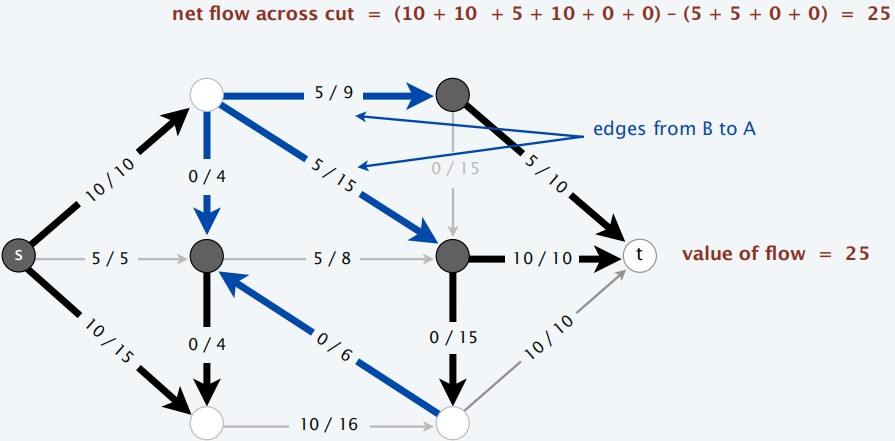

## Flows and cuts: relationship (cont.)

**Flow value lemma**. Let $f$ be any flow and let $(A, B)$ be any cut. Then, the value of the flow $f$ equals the net flow across the cut $(A, B)$.

$$val(f) = \sum_{e\ \text{out}\ A} f(e) - \sum_{e\ \text{into}\ A} f(e)$$

**Pf**.

$$\begin{aligned}
val(f) & = \sum_{e\ \text{out}\ s} f(e) - \sum_{e\ \text{into}\ s} f(e) \\
& = \sum_{v \in A} (\sum_{e\ \text{out}\ v} f(e) - \sum_{e\ \text{into}\ v} f(e)) \\
& = \sum_{e\ \text{out}\ A} f(e) - \sum_{e\ \text{into}\ A} f(e) \\
\end{aligned}$$

## Flows and cuts: duality

**Weak duality**. Let $f$ be any flow and $(A, B)$ be any cut. Then, $val(f) \le cap(A, B)$.  
**Pf**.

$$\begin{aligned}
val(f) & = \sum_{e\ \text{out}\ A} f(e) - \sum_{e\ \text{into}\ A} f(e) \\
& \le \sum_{e\ \text{out}\ A} f(e) \\
& \le \sum_{e\ \text{out}\ A} c(e) \\
& = cap(A, B) \\
\end{aligned}$$

## Certificate of optimality

**Corollary**. Let $f$ be a flow and let $(A, B)$ be any cut. If $val(f) = cap(A, B)$, then $f$ is a max flow and $(A, B)$ is a min cut.  
**Pf**.

- For any flow $f'$: $val(f') \le cap(A, B) = val(f)$.
- For any cut $(A', B')$: $cap(A', B') \ge val(f) = cap(A, B)$.

## Max-flow min-cut theorem I

**Max-flow min-cut theorem**. [strong duality] Value of a max flow = capacity of a min cut.

**Augmenting path theorem**. A flow $f$ is a max flow iff no augmenting paths.

**Pf**. The following three conditions are equivalent for any flow $f$:

- A. There exists a cut $(A, B)$ such that $cap(A, B) = val(f)$.
- B. $f$ is a max flow.
- C. There is no augmenting path with respect to $f$.
  - Or, if Ford-Fulkerson terminates, then f is max flow.

[ $A \Rightarrow B$ ]

- Weak duality corollary.

## Max-flow min-cut theorem II

**Max-flow min-cut theorem**. [strong duality] Value of a max flow = capacity of a min cut.

**Augmenting path theorem**. A flow $f$ is a max flow iff no augmenting paths.

**Pf**. The following three conditions are equivalent for any flow $f$:

- A. There exists a cut $(A, B)$ such that $cap(A, B) = val(f)$.
- B. $f$ is a max flow.
- C. There is no augmenting path with respect to $f$.

[ $B \Rightarrow C$ ] We prove contrapositive: $\lnot C \Rightarrow \lnot B$.

- Suppose that there is an augmenting path with respect to $f$.
- Can improve flow $f$ by sending flow along this path.
- Thus, $f$ is not a max flow, contradiction.

## Max-flow min-cut theorem III

[ $C \Rightarrow A$ ]

- Let $f$ be a flow with no augmenting paths.
- Let $A$ = set of nodes reachable from $s$ in residual network $G_f$.
- By definition of $A$: $s \in A$.
- By definition of flow $f$: $t \notin A$.

$$\begin{aligned}
val(f) & = \sum_{e\ \text{out}\ A} f(e) - \sum_{e\ \text{into}\ A} f(e) \\
& = \sum_{e\ \text{out}\ A} c(e) - 0 \\
& = cap(A, B) \\
\end{aligned}$$

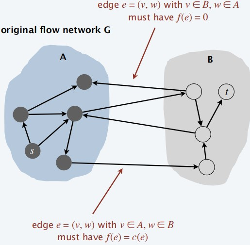

## Computing a minimum cut

**Theorem**. Given any max flow $f$, can compute a min cut $(A, B)$ in $O(m)$ time.  
**Pf**. Let $A$ = set of nodes reachable from $s$ in residual network $G_f$.

- argument from previous slide implies that capacity of $(A, B)$ = value of flow $f$

# Capacity-scaling algorithm

## Ford-Fulkerson: analysis

**Assumption**. Every edge capacity $c(e)$ is an integer between $1$ and $C$.

**Integrality invariant**. Throughout Ford-Fulkerson, every edge flow $f(e)$ and residual capacity $c_f(e)$ is an integer.  
**Pf**. By induction on the number of augmenting paths.

**Theorem**. Ford-Fulkerson terminates after at most $val(f^\ast) \le nC$ augmenting paths, where $f^\ast$ is a max flow.  
**Pf**. Each augmentation increases the value of the flow by at least $1$.

**Corollary**. The running time of Ford-Fulkerson is $O(m nC)$.  
**Pf**. Can use either BFS or DFS to find an augmenting path in $O(m)$ time.

**Integrality theorem**. There exists an integral max flow $f^\ast$.  
**Pf**. Since Ford-Fulkerson terminates, theorem follows from integrality invariant (and augmenting path theorem).

## Ford-Fulkerson: exponential example

**Q**. Is generic Ford-Fulkerson algorithm poly-time in input size ($m, n, \log C$)?  
**A**. No. If max capacity is $C$, then algorithm can take $\ge C$ iterations.

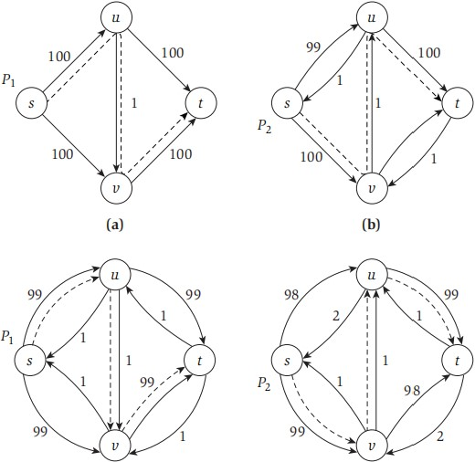

- See Demo.

## Quiz: Ford-Fulkerson

The Ford-Fulkerson algorithm is guaranteed to terminate if the edge capacities are …

**A**. Rational numbers.  
**B**. Real numbers.  
**C**. Both A and B.  
**D**. Neither A nor B.

Rational = integer / integer

## Choosing good augmenting paths

**Use care when selecting augmenting paths**.

- Some choices lead to exponential algorithms.
- Clever choices lead to polynomial algorithms.

**Pathology**. When edge capacities can be irrational, no guarantee that Ford-Fulkerson terminates (or converges to a maximum flow)!

- See Demo.

**Goal**. Choose augmenting paths so that:

- Can find augmenting paths efficiently.
- Few iterations.

## Choosing good augmenting paths (cont.)

**Goal**. Choose augmenting paths so that:

- Can find augmenting paths efficiently.
- Few iterations.

**Choose augmenting paths with**:

- Max bottleneck capacity (“fattest”).
  - How to find?
  - [Next] Sufficiently large bottleneck capacity.
- [Ahead] Fewest edges.

## Capacity-scaling

**Overview**. Choosing augmenting paths with “large” bottleneck capacity.

- Maintain scaling parameter $\Delta$.
- Let $G_f(\Delta)$ be the part of the residual network containing only those edges with capacity $\ge \Delta$.
- Any augmenting path in $G_f(\Delta)$ has bottleneck capacity $\ge \Delta$.

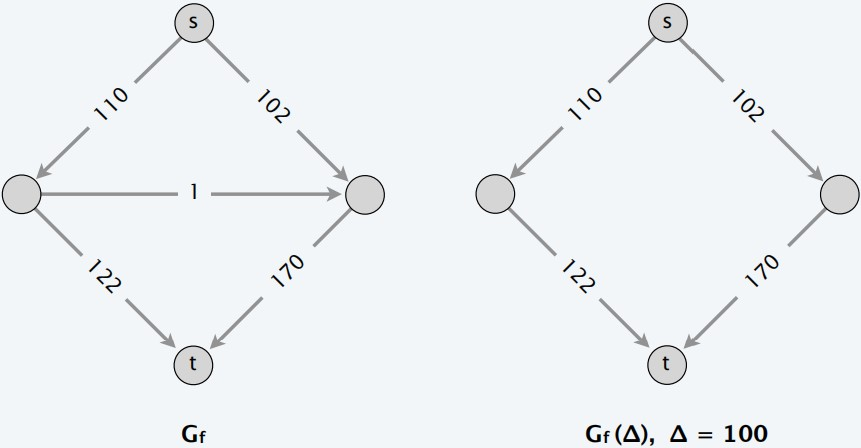

## Capacity-scaling: algorithm

`CAPACITY-SCALING`($G$)

1. FOREACH edge $e \in E$: $f(e) = 0$;
2. $\Delta$ = largest power of $2 \le C$;
3. WHILE ($\Delta \ge 1$)
   1. $G_f(\Delta)$ = $\Delta$-residual network of $G$ with respect to flow $f$;
   2. WHILE (there exists an $s \leadsto t$ path $P$ in $G_f(\Delta)$)
      1. $f$ = `AUGMENT`($f, c, P$);
      2. Update $G_f(\Delta)$;
   3. $\Delta = \Delta / 2$;
4. RETURN f;

## Capacity-scaling: correctness

**Assumption**. All edge capacities are integers between $1$ and $C$.

**Invariant**. The scaling parameter $\Delta$ is a power of $2$.  
**Pf**. Initially a power of $2$; each phase divides $\Delta$ by exactly $2$.

**Integrality invariant**. Throughout the algorithm, every edge flow $f(e)$ and residual capacity $c_f(e)$ is an integer.  
**Pf**. Same as for generic Ford-Fulkerson.

**Theorem**. If capacity-scaling algorithm terminates, then $f$ is a max flow.  
**Pf**.

- By integrality invariant, when $\Delta = 1 \Rightarrow G_f(\Delta) = G_f$.
- Upon termination of $\Delta = 1$ phase, there are no augmenting paths.
- Result follows augmenting path theorem.

## Capacity-scaling: analysis

**Lemma 1**. There are $1 + \lfloor \log_2 C \rfloor$ scaling phases.  
**Pf**. Initially $C/ 2 < \Delta \le C$; decreases by a factor of $2$ in each iteration.

**Lemma 2**. Let $f$ be the flow at the end of a $\Delta$-scaling phase. Then, the max-flow value $\le val(f) + m \Delta$.  
**Pf**. Next slide.

**Lemma 3**. There are $\le 2m$ augmentations per scaling phase.  
**Pf**.

- Let $f$ be the flow at the beginning of a $\Delta$-scaling phase.
- Lemma 2 $\Rightarrow$ max-flow value $\le val(f) + m (2 \Delta)$.
- Each augmentation in a $\Delta$-phase increases $val(f)$ by at least $\Delta$.

## Capacity-scaling: analysis (cont.)

**Lemma 2**. Let $f$ be the flow at the end of a $\Delta$-scaling phase. Then, the max-flow value $\le val(f) + m \Delta$.  
**Pf**.

- We show there exists a cut $(A, B)$ such that $cap(A, B) \le val(f) + m \Delta$.
- Choose $A$ to be the set of nodes reachable from $s$ in $G_f(\Delta)$.
- By definition of $A$: $s \in A$; By definition of flow $f$: $t \notin A$.

$$\begin{aligned}
val(f) & = \sum_{e\ \text{out}\ A} f(e) - \sum_{e\ \text{into}\ A} f(e) \\
& \ge \sum_{e\ \text{out}\ A} (c(e) - \Delta) - \sum_{e\ \text{into}\ A} \Delta \\
& \ge \sum_{e\ \text{out}\ A} c(e) - \sum_{e\ \text{out}\ A} \Delta - \sum_{e\ \text{into}\ A} \Delta \\
& \ge cap(A, B) m\Delta \\
\end{aligned}$$

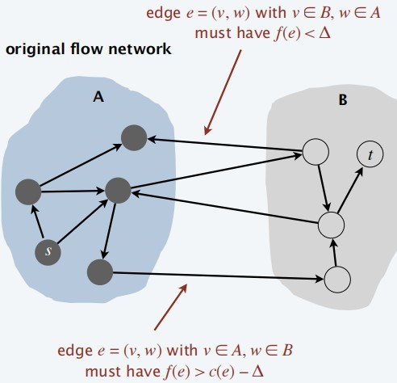

## Capacity-scaling: running time

**Lemma 1**. There are $1 + \lfloor \log_2 C \rfloor$ scaling phases.

**Lemma 2**. Let $f$ be the flow at the end of a $\Delta$-scaling phase. Then, the max-flow value $\le val(f) + m \Delta$.

**Lemma 3**. There are $\le 2m$ augmentations per scaling phase.

**Theorem**. The capacity-scaling algorithm takes $O(m^2 \log C)$ time.  
**Pf**.

- Lemma 1 + Lemma 3 $\Rightarrow$ $O(m log C)$ augmentations.
- Finding an augmenting path takes $O(m)$ time.

# Shortest augmenting paths

## Shortest augmenting

**Q**. How to choose next augmenting path in Ford-Fulkerson?  
**A**. Pick one that uses the fewest edges (*via BFS*).

`SHORTEST-AUGMENTING-PATH`($G$)

1. FOREACH $e \in E$: $f(e) = 0$;
2. $G_f$ = residual network of $G$ with respect to flow $f$;
3. WHILE (there exists an $s \leadsto t$ path in $G_f$)
   1. $P$ = `BREADTH-FIRST-SEARCH`($G_f$);
   2. $f$ = `AUGMENT`($f, c, P$);
   3. Update $G_f$;
4. RETURN $f$;

## Shortest augmenting: analysis overview

**Lemma 1**. The length (number of edges) of a shortest augmenting path never decreases.  
**Pf**. Ahead.

**Lemma 2**. After at most $m$ shortest-path augmentations, the length of a shortest augmenting path strictly increases.  
**Pf**. Ahead.

**Theorem**. The shortest-augmenting-path algorithm takes $O(m^2 n)$ time.  
**Pf**.

- $O(m)$ time to find a shortest augmenting path via BFS.
- There are $\le m n$ augmentations.
  - [from Lemmas] at most $m$ augmenting paths of length $k$
  - [simple path] at most $n−1$ different lengths

## Level graph

**Def**. Given a digraph $G = (V, E)$ with source $s$, its **level graph** is defined by:

- l(v) = number of edges in shortest $s \leadsto v$ path.
- $L_G = (V, E_G)$ is the subgraph of $G$ that contains only those edges $(v, w) \in E$ with $l(w) = l(v) + 1$.

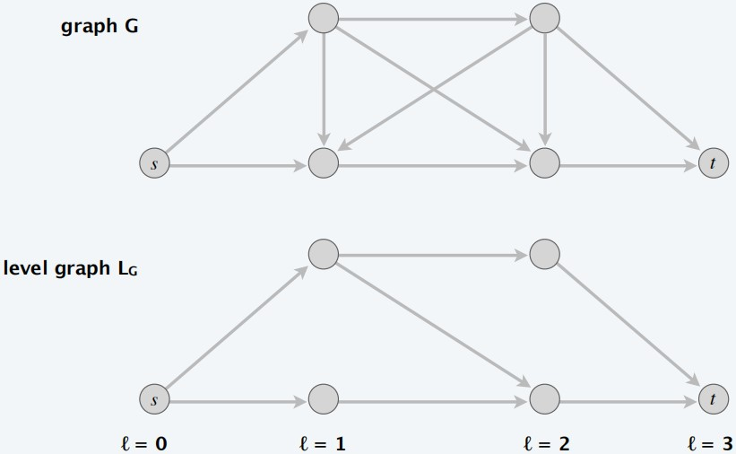

## Level graph (cont.)

**Key property**. $P$ is a shortest $s \leadsto v$ path in $G$ iff $P$ is an $s \leadsto v$ path in $L_G$.

- nodes are ordered the same with BFS
- “back-edges” are removed

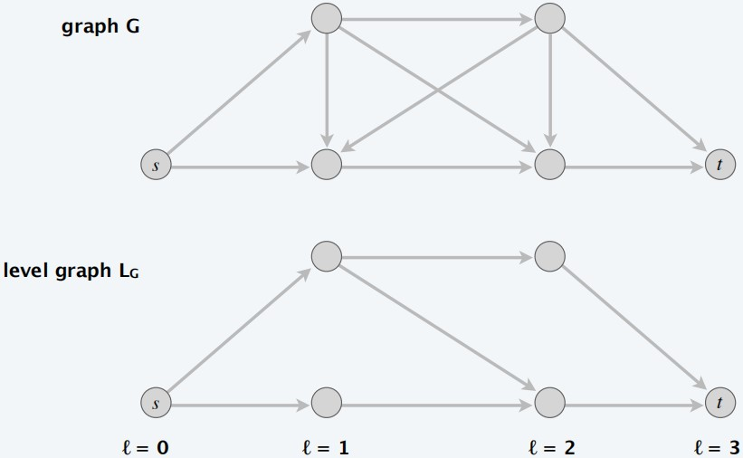

## Shortest augmenting: Lemma 1

**Lemma 1**. The length of a shortest augmenting path never decreases.

- Let $f$ and $f'$ be flow before and after a shortest-path augmentation.
- Let $L_G$ and $L_Gʹ$ be level graphs of $G_f$ and $G_f'$.
- Only back edges added to $G_f'$; bottleneck broken.
- any $s \leadsto t$ path uses back edge is longer than previous length.

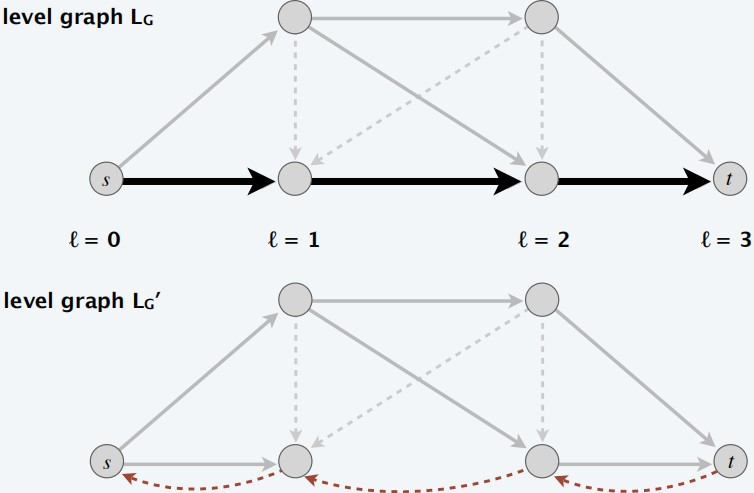

## Shortest augmenting: Lemma 2

**Lemma 2**. After at most $m$ shortest-path augmentations, the length of a shortest augmenting path strictly increases.

- At least one (bottleneck) edge is deleted from $L_G$ per augmentation.
- No new edge added to $L_G$ until shortest path length strictly increases.

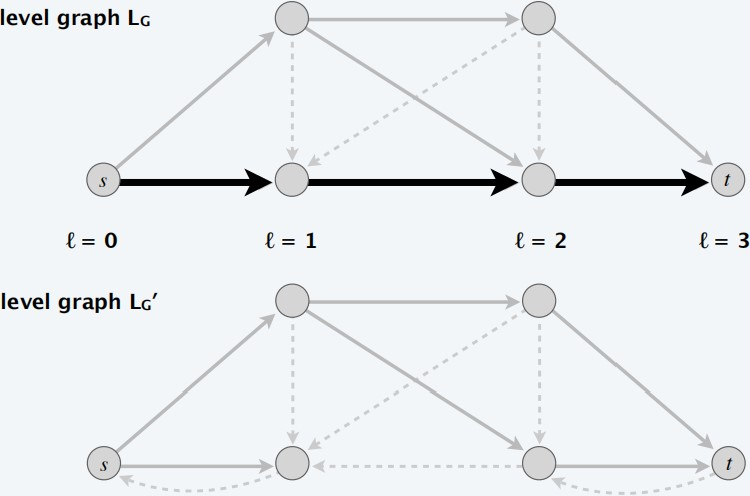

## Shortest augmenting: analysis

**Lemma 1**. The length (number of edges) of a shortest augmenting path never decreases.

**Lemma 2**. After at most $m$ shortest-path augmentations, the length of a shortest augmenting path strictly increases.

**Theorem**. The shortest-augmenting-path algorithm takes $O(m^2 n)$ time.

**Note**. $Θ(m n)$ augmentations necessary for some flow networks.

- Try to decrease time per augmentation instead.
  - Simple idea $\Rightarrow O(mn^2 )$ [Dinitz 1970]
  - Dynamic trees $\Rightarrow O(m n \log n)$ [Sleator-Tarjan 1983]

# Dinitz’ algorithm

## Dinitz’ algorithm

**Two types of augmentations**.

- Normal: length of shortest path does not change.
- Special: length of shortest path strictly increases.

**Phase of normal augmentations**.

- Construct level graph $L_G$.
- Start at $s$, advance along an edge in $L_G$ until reach $t$ or get stuck.
  - If reach $t$, augment flow; update $L_G$; and restart from $s$.
  - If get stuck, delete node from $L_G$ and retreat to previous node.

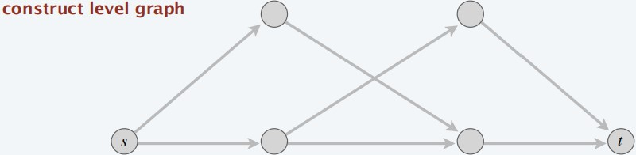

## Demo: Dinitz’ algorithm

## Dinitz’ algorithm (refined)

`INITIALIZE`($G, f$)

1. $L_G =$ level-graph of $G_f$;
2. $P = \emptyset$;
3. GOTO `ADVANCE`($s$);

`RETREAT`($v$)

1. IF ($v = s$) STOP;
2. ELSE
   1. Delete $v$ (and all incident edges) from $L_G$;
   2. Remove last edge $(u, v)$ from $P$;
   3. GOTO `ADVANCE`($u$);

`ADVANCE`($v$)

1. IF ($v = t$) `AUGMENT`($P$);
   1. Remove saturated edges from $L_G$;
   2. $P = \emptyset$;
   3. GOTO `ADVANCE`($s$);
2. IF (there exists edge $(v, w) \in L_G$)
   1. Add edge $(v, w)$ to $P$;
   2. GOTO `ADVANCE`($w$);
3. ELSE
   1. GOTO `RETREAT`($v$);

## Quiz: level graph

How to compute the level graph $L_G$ efficiently?

**A**. Depth-first search.  
**B**. Breadth-first search.  
**C**. Both A and B.  
**D**. Neither A nor B.

## Dinitz’ algorithm: analysis

**Lemma**. A phase can be implemented to run in $O(m n)$ time.  
**Pf**.

- Initialization happens once per phase. $O(m)$ using BFS.
- At most $m$ augmentations per phase. $O(mn)$ per phase.
  - (because an augmentation deletes at least one edge from $L_G$)
- At most $n$ retreats per phase. $O(m + n)$ per phase
  - (because a retreat deletes one node from $L_G$)
- At most $mn$ advances per phase. O(mn) per phase
  - (because at most $n$ advances before retreat or augmentation)

**Theorem**. [Dinitz 1970] Dinitz’ algorithm runs in $O(mn^2)$ time.  
**Pf**.

- By Lemma, $O(mn)$ time per phase.
- At most $n−1$ phases (as in shortest-augmenting-path analysis).

## Maximum-flow algorithms: practice

**Push-relabel algorithm**. [Goldberg-Tarjan 1988] Increases flow one edge at a time instead of one augmenting path at a time.

- (SECTION 7.4, Algorithm Design.)

**Caveat**. Worst-case running time is generally not useful for predicting or comparing max-flow algorithm performance in practice.

**Best in practice**. Push-relabel method with gap relabeling: $O(m^{3/2})$ in practice.

## Maximum-flow algorithms: CV

**Computer vision**. Different algorithms work better for some dense problems that arise in applications to computer vision.

- [Boykov and Kolmogorov 2004] An experimental comparison of min-cut/max- flow algorithms for energy minimization in vision.

# Simple unit-capacity networks

## Quiz: bipartite matching

Which max-flow algorithm to use for bipartite matching?

**A**. Ford-Fulkerson: $O(m n C)$.  
**B**. Capacity scaling: $O(m^2 log C)$.  
**C**. Shortest augmenting path: $O(m^2 n)$.  
**D**. Dinitz’ algorithm: $O(m n^2)$.

D. the graph may be dense.

## Simple unit-capacity networks

**Def**. A flow network is a **simple unit-capacity network** if:

- Every edge has capacity 1.
- Every node (other than $s$ or $t$) has exactly one entering edge, or exactly one leaving edge, or both.

**Ex**. Bipartite matching.

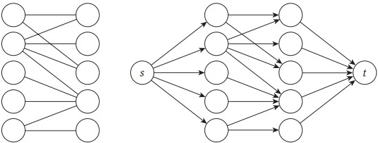

**Property**. Let $G$ be a simple unit-capacity network and let $f$ be a 0-1 flow. Then, residual network $G_f$ is also a simple unit-capacity network.

## Unit-capacity: algorithm overview

**Shortest-augmenting-path algorithm**.

- Normal augmentation: length of shortest path does not change.
- Special augmentation: length of shortest path strictly increases.

**Theorem**. [Even-Tarjan 1975] In simple unit-capacity networks, Dinitz’ algorithm computes a maximum flow in $O(m n^{1/2})$ time.  
**Pf**.

- Lemma 1. Each phase of normal augmentations takes $O(m)$ time.
- Lemma 2. After $n^{1/2}$ phases, $val(f) \ge val(f^\ast) - n^{1/2}$.
- Lemma 3. After $\le n^{1/2}$ additional augmentations, flow is optimal.

**Lemma 3**. After $\le n^{1/2}$ additional augmentations, flow is optimal.  
**Pf**. Each augmentation increases flow value by at least 1.

**Lemma 1 and Lemma 2**. Ahead.

## Unit-capacity: Dinitz’

**Phase of normal augmentations**.

- Construct level graph $L_G$.
- Start at $s$, advance along an edge in $L_G$ until reach t or get stuck.
- If reach $t$, augment flow; update $L_G$; and restart from $s$.
- If get stuck, delete node from $L_G$ and go to previous node.

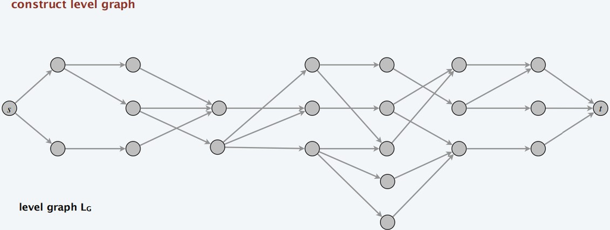

## Demo: Dinitz’ for Unit-capacity

## Unit-capacity: Lemma 1

**Phase of normal augmentations**.

- Construct level graph $L_G$.
- Start at $s$, advance along an edge in $L_G$ until reach t or get stuck.
- If reach $t$, augment flow; update $L_G$; and restart from $s$.
- If get stuck, delete node from $L_G$ and go to previous node.

**Lemma 1**. A phase of normal augmentations takes $O(m)$ time.  
**Pf**.

- $O(m)$ to create level graph $L_G$.
- $O(1)$ per edge (each edge involved in at most one advance, retreat, and augmentation).
- $O(1)$ per node (each node deleted at most once).

## Quiz: non-unit-capacity

Consider running advance-retreat algorithm in a unit-capacity network (but not necessarily a simple one). What is running time?

**A**. $O(m)$.  
**B**. $O(m^{3/2})$.  
**C**. $O(m n)$.  
**D**. May not terminate.

Hint: both indegree and outdegree of a node can be larger than 1.

A. may take $m$ operations per node

## Unit-capacity: Lemma 2

**Lemma 2**. After $n^{1/2}$ phases, $val(f) \ge val(f^\ast) - n^{1/2}$.

- After $n^{1/2}$ phases, length of shortest augmenting path is $> n^{1/2}$.
- Thus, level graph has $\ge n^{1/2}$ levels (not including levels for $s$ or $t$).
- Let $1 \le h \le n^{1/2}$ be a level with min number of nodes $\Rightarrow |V_h| \le n^{1/2}$.

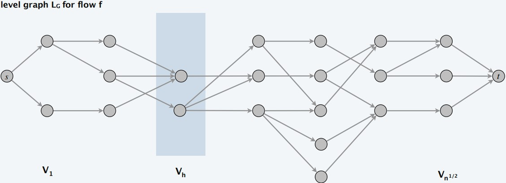

## Unit-capacity: Lemma 2 (cont.)

**Lemma 2**. After $n^{1/2}$ phases, $val(f) \ge val(f^\ast) - n^{1/2}$.

- After $n^{1/2}$ phases, length of shortest augmenting path is $> n^{1/2}$.
- Thus, level graph has $\ge n^{1/2}$ levels (not including levels for $s$ or $t$).
- Let $1 \le h \le n^{1/2}$ be a level with min number of nodes $\Rightarrow |V_h| \le n^{1/2}$.
- Let $A = \{v : l(v) < h\} \cup \{v : l(v) = h\ \text{and}\ v\ \text{has}\ \le 1\ \text{outgoing residual edge}\}$.
- $cap_f (A, B) \le |V_h| \le n^{1/2} \Rightarrow val(f) \ge val(f^\ast) - n^{1/2}$.

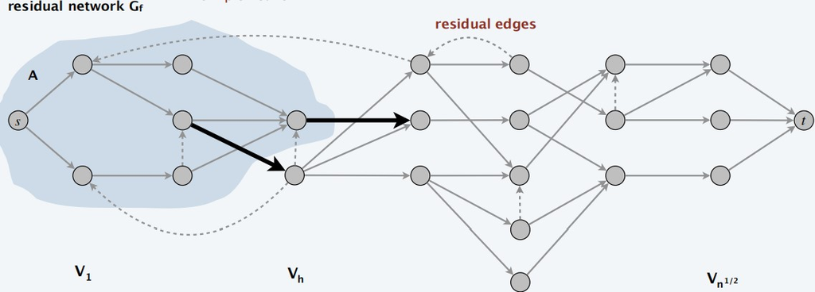

## Unit-capacity: analysis

**Theorem**. [Even-Tarjan 1975] In simple unit-capacity networks, Dinitz’ algorithm computes a maximum flow in $O(m n^{1/2})$ time.  
**Pf**.

- Lemma 1. Each phase of normal augmentations takes $O(m)$ time.
- Lemma 2. After $n^{1/2}$ phases, $val(f) \ge val(f^\ast) - n^{1/2}$.
- Lemma 3. After $\le n^{1/2}$ additional augmentations, flow is optimal.

**Corollary**. Dinitz’ algorithm computes max-cardinality bipartite matching in $O(m n^{1/2})$ time.